# Guinea Pig Tooth Length by Dose and Delivery Method

davegoblue

March 9, 2016

## Overview and Synopsis

This analysis explores variability in Guinea Pig tooth length vs. dose and delivery method based on the ToothGrowth dataset available in the R datasets package.

There is a significant (p<0.001) difference in tooth length for each pairwise comparison of doses 0.5, 1.0, and 2.0. However, we fail to reject the null hypothesis (p=0.061) that tooth length is independent of delivery method.

## Analysis

### *Data Loading and Exploratory Data Analysis*

The prepackaged dataset is loaded using a data() call and briefly examined. See Appendix for R code (the below are created with echo=FALSE).

```
## 'data.frame':    60 obs. of  3 variables:
##  $ len : num  4.2 11.5 7.3 5.8 6.4 10 11.2 11.2 5.2 7 ...
##  $ supp: Factor w/ 2 levels "OJ","VC": 2 2 2 2 2 2 2 2 2 2 ...
##  $ dose: num  0.5 0.5 0.5 0.5 0.5 0.5 0.5 0.5 0.5 0.5 ...
```

```
## [1] "There are 0 NA in the data"
```

```
##
##      0.5  1  2
##   OJ  10 10 10
##   VC  10 10 10
```

The dataset contains 60 observations across 3 variables (len=tooth length, supp=delivery method, dose=dose). There are no NA, with 10 observations for each overlap of dose vs. delivery (supp).

Additionally, a histogram and boxplot are created for simple exploratory data analysis (see Appendix for R code, this was run with echo=FALSE):

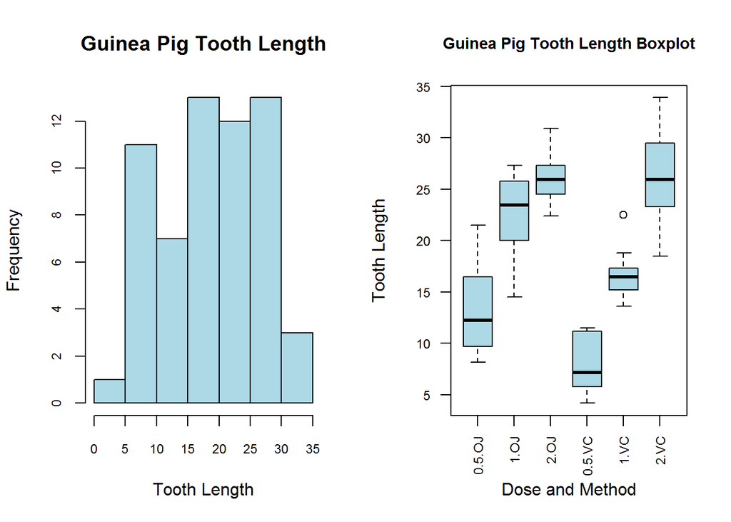

While tooth length is not normally distributed, the data are roughly mounded and symmetric. At a glance, tooth length appears to vary depending on dose (very likely) and method (possibly).

### *Key Assumptions and Questions*

While ANOVA followed by Tukey HSD, or non-parametric tests might be appropriate given our data, we are asked to avoid these. We instead seek to answer two questions with the data:

- Does tooth length significantly vary with method?
- Does tooth length significantly vary with dose?

With n=10 in each bucket and seeming differences in variance, we would be on the low end of trying to detect interaction (dose * method). Instead, we use pairwise t-tests to answer the questions above, with alpha=0.05 and Bonferroni adjustment for dose p-values (there are 3 comparisons).

The following assumptions appear to support our approach:

- While non-normal, tooth length is roughly symmetric, mound shaped, and without extreme outliers
- With n=20 and n=30 per group, T-tests will be reasonably close to following CLT given underlying data that is symmetric, mounded, and without extreme outliers
- While we ignore interaction, our experiment design helps control for it with equal numbers of each dose in each method. This reduces the risk that dose and method confound one another

### *Hypothesis Tests and Confidence Intervals*

The null hypotheses are that 1) tooth length is independent of delivery method, and 2) tooth length is independent of dose. The alternative hypotheses are that dosage or method influence tooth length (two-sided). We assume alpha=0.05 and apply a Bonferroni adjustment for p-values of the three comparisons of dose.

#### **Hypothesis Test #1: Length vs. Delivery Method**

Ho: There is no difference in tooth length by delivery method (supp)  
Ha: There is a difference in tooth length by delivery method  
alpha: 0.05, two-sided

We run a t-test for tooth length vs. delivery method assuming unequal variance and note that the 95% confidence interval overlaps with zero difference. We fail to reject the null hypothesis that there is no difference in tooth length by delivery method. See Appendix for R code (run here with echo=FALSE).

```
## [1] "The 95% CI for difference in means by delivery method is: -0.2 to 7.6"
```

```
## [1] "The associated p-value is 0.061"
```

#### **Hypothesis Test #2: Length vs. Dose**

Ho: There is no difference in tooth length by dose  
Ha: There is a difference in tooth length by dose  
alpha: 0.05, two-sided, Bonferroni adjusted to keep FWER=alpha

We run pairwise t-tests for tooth length vs. dose assuming unequal variance with the Bonferroni adjustment (3 total comparisons). The p-values are miniscule for each comparison (P<0.001), and we thus reject the null hypothesis in favor of the alternate hypothesis that tooth length varies with dose.

```r
tDose <- pairwise.t.test(ToothGrowth$len , ToothGrowth$dose ,
                         pool.sd=FALSE, p.adjust.method = "bonferroni")
tDose$p.value
```

```
##            0.5            1
## 1 3.804902e-07           NA
## 2 1.319257e-13 5.719289e-05
```

## Conclusion

We conclude that tooth length in guinea pigs varies significantly with dose. We fail to reject the other null hypothesis that guinea pig tooth length does not vary with delivery method.

**Technical Note:** My machine considers the executable required to run knit2pdf to be potential malware. This PDF is instead generated using Acrobat DC to convert the html output of knit2html.

## Appendix

### *R Code for Exploratory Data Analysis*

The below code was run using echo=FALSE to load and examine the data (first chunk) and then to create a histogram and boxplot (second chunk). It is shown here using eval=FALSE for reference:

```r
data(ToothGrowth)
str(ToothGrowth)
print(paste0("There are ",sum(is.na(ToothGrowth))," NA in the data"))
table(ToothGrowth$supp,ToothGrowth$dose)
```

```r
par(mfcol=c(1,2))
hist(ToothGrowth$len,col="light blue",main="Guinea Pig Tooth Length",
     xlab="Tooth Length",cex.axis=0.75
     )
boxplot(len ~ dose + supp, data=ToothGrowth,
        col="light blue",las=2,cex.axis=0.75
        )
title(main="Guinea Pig Tooth Length Boxplot",cex.main=0.9,
      ylab="Tooth Length",xlab="Dose and Method"
      )
par(mfcol=c(1,1))
```

### *R Code for Hypothesis Test #1: Tooth Length vs. Method*

The below code was run using echo=FALSE to create the confidence interval and p-value for comparing the mean length by the two methods. It is shown here using eval=FALSE for reference:

```r
tMethod <- t.test(len ~ supp, data=ToothGrowth)
print(paste0("The 95% CI for difference in means by delivery method is: ",
             round(tMethod$conf.int[[1]],1)," to ",
             round(tMethod$conf.int[[2]],1)
             )
      )
print(paste0("The associated p-value is ", round(tMethod$p.value,3)))
```

### *Extension of Hypothesis Test #2: Length vs. Dose*

Since we found significant differences in tooth length vs. dose (two-sided), it may be interesting to explore the impact of these differences further. We first examine the mean tooth length by dosage and see that there is a positive relationship where tooth growth is higher for higher dose:

```r
tapply(ToothGrowth$len,ToothGrowth$dose,FUN=mean)
```

```
##    0.5      1      2
## 10.605 19.735 26.100
```

We run t-tests for each of the 3 possible pairings of dosage:

```r
tDose05_10 <- t.test(len ~ dose, data=ToothGrowth[ToothGrowth$dose != 2,])
tDose05_20 <- t.test(len ~ dose, data=ToothGrowth[ToothGrowth$dose != 1,])
tDose10_20 <- t.test(len ~ dose, data=ToothGrowth[ToothGrowth$dose != 0.5,])
```

We then create a data frame for the outputs, being mindful to convert the order to large dose minus small dose (the opposite of what our t-test ran):

```r
diff05_10 <- tDose05_10$estimate[2] - tDose05_10$estimate[1]
diff05_20 <- tDose05_20$estimate[2] - tDose05_20$estimate[1]
diff10_20 <- tDose10_20$estimate[2] - tDose10_20$estimate[1]
ci05_10 <- -tDose05_10$conf.int ## Negate so it is 1.0 vs. 0.5
ci05_20 <- -tDose05_20$conf.int ## Negate so it is 2.0 vs. 0.5
ci10_20 <- -tDose10_20$conf.int ## Negate so it is 2.0 vs. 1.0

tDoseAll <- data.frame(dataCompare=c("1.0 vs. 0.5","2.0 vs. 0.5",
                                     "2.0 vs. 1.0"
                                     ),
                       meanDiff=c(diff05_10,diff05_20,diff10_20),
                       highCI=c(ci05_10[1],ci05_20[1],ci10_20[1]),
                       lowCI=c(ci05_10[2],ci05_20[2],ci10_20[2])
                       )
```

And, we examine the data as well as plotting these 95% confidence intervals using ggplot:

```r
foo <- function(changethis) { round(changethis,1) }
tDosePrint <- tDoseAll
tDosePrint[,2:4] <- apply(tDosePrint[,2:4],2,FUN=foo)
tDosePrint[,c(1,4,2,3)]
```

```
##   dataCompare lowCI meanDiff highCI
## 1 1.0 vs. 0.5   6.3      9.1   12.0
## 2 2.0 vs. 0.5  12.8     15.5   18.2
## 3 2.0 vs. 1.0   3.7      6.4    9.0
```

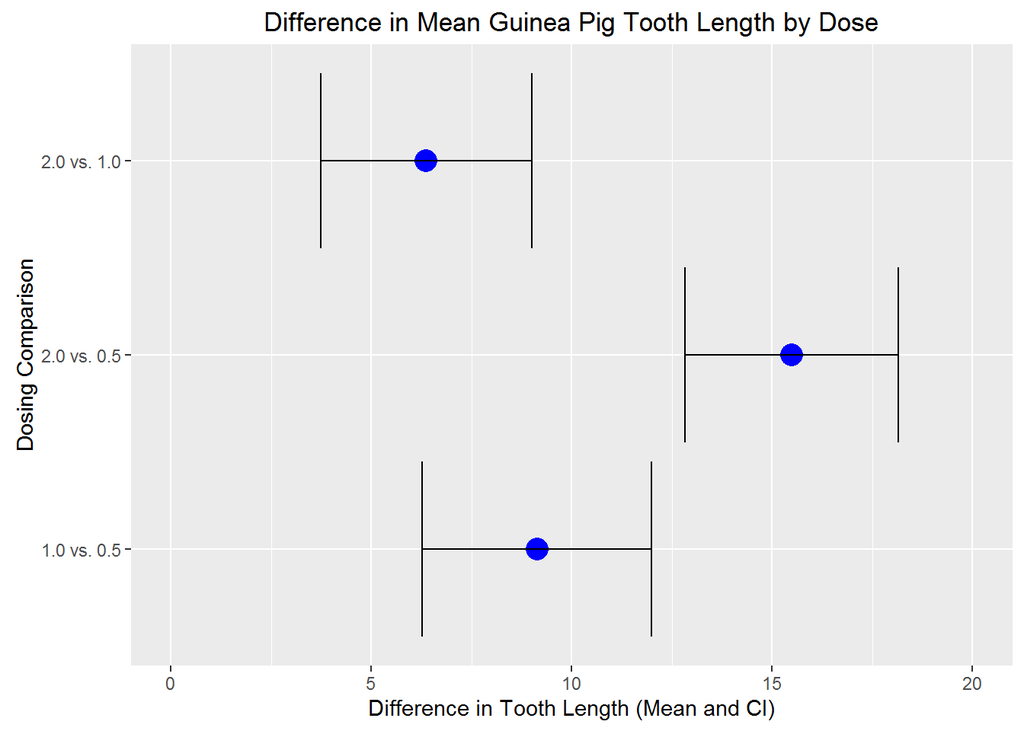

```r
library(ggplot2)
g <- ggplot(data=tDoseAll, mapping=aes(x=meanDiff,y=dataCompare))
g <- g + geom_point(size=5,col="blue") +
         geom_errorbarh(aes(xmax=highCI, xmin=lowCI))
g + labs(title="Difference in Mean Guinea Pig Tooth Length by Dose",
         x="Difference in Tooth Length (Mean and CI)",
         y="Dosing Comparison"
         ) + xlim(0,20)
```

Due caution should be used in interpretation since the Bonferroni correction is **not** applied while creating these CI. Nonetheless, the analysis confirms that there is a large, positive relationship between increasing dose and increasing tooth length.